# What Makes a Match?

#### Genderwise Comparison of Numerical Variables Within Matches

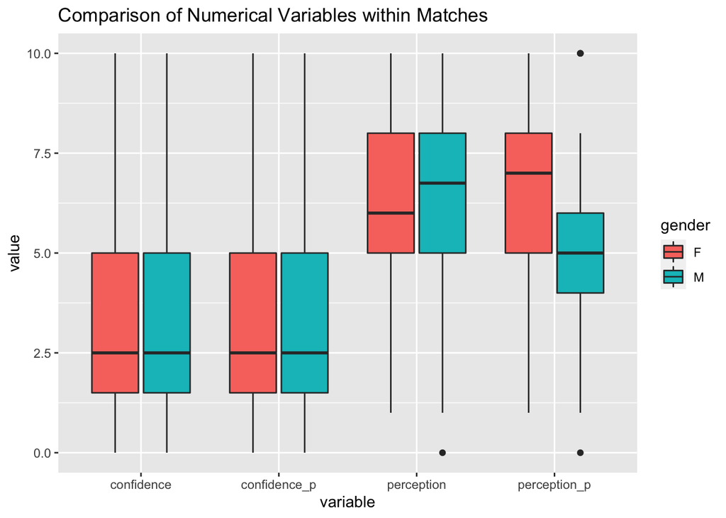

```r
df8 <- matches[, c("gender", "confidence", "confidence_p", "perception", "perception_p")]
ggplot(melt(df8, id.var = "gender"), aes(x=variable, y=value, fill = gender)) + geom_boxplot() + ggtitle("Comparison of Numerical Variables within Matches")
```

All variables seem to be distributed similarly between both genders, except for partner perception of interest. Men seem to have a lower partner perception of interest than females, meaning that men’s partners (i.e. the females of the study) thought that the men were less interested in them when compared to the inverse situation.

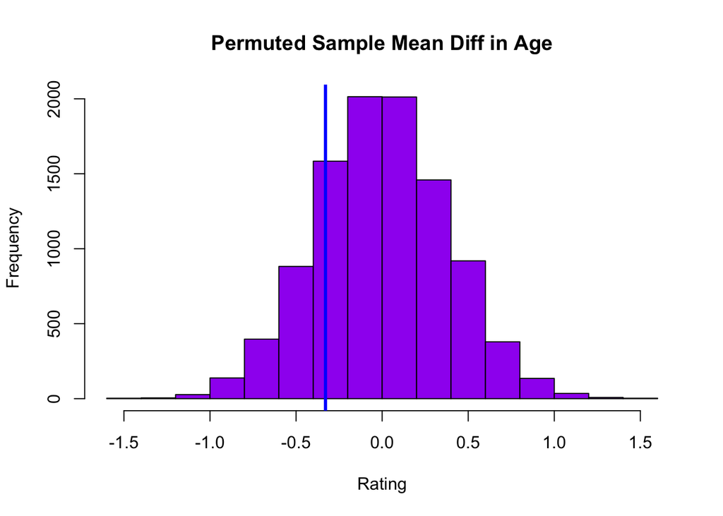

```r
## Permutation Test
actDiff <- by(matches$age, matches$gender, mean)
actDiff <- actDiff[1] - actDiff[2]
N <- 10000
diffvals <- rep(NA, N)
for (i in 1:N) {
  fakeGender <- sample(matches$gender)
  diffvals[i] <- mean(matches$age[fakeGender == "F"])-mean(matches$age[fakeGender == "M"])
}

# histogram of permuted MEAN differences
hist(diffvals, col = "purple",
     main = "Permuted Sample Mean Diff in Age", xlab = "Rating")
abline(v = actDiff, col="blue", lwd=3)
```

```r
mean(abs(diffvals) >= abs(actDiff))
```

```
## [1] 0.3927
```

As seen above, there is not a significant difference in the means of age by gender. This is demonstrated by p = 0.39 > alpha (0.05), thus we cannot reject the null hypothesis. For this data, we cannot say that the matches are typically between different age pairs. This is makes sense considering how narrow the age range was to begin with, being on a college campus.

#### Analyzing Catagorical Variables within Matches

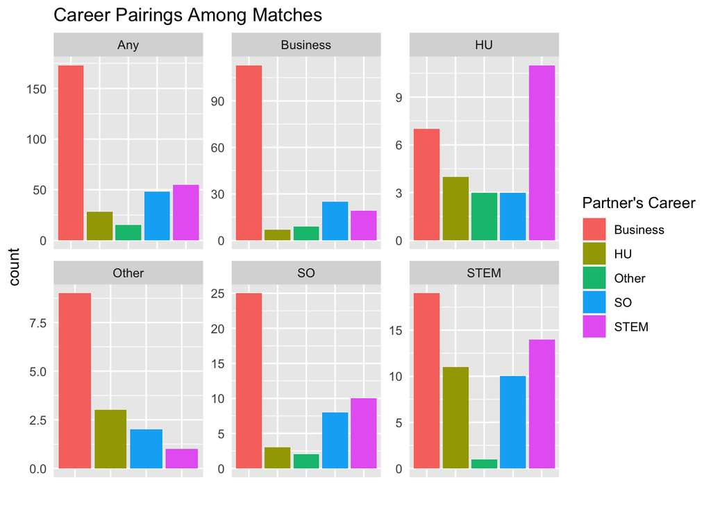

```r
#barplot(table(db$career), col = c(2:6), main = 'Barplot of Careers: Entire Data', xlab = 'Career', ylab = '# of people')
df3 <- matches[, c("career", "career_p")]
df4 <- df3
df4$career <- recode(df4$career, "'Business' = 'Any'; 'STEM' = 'Any'; 'HU' = 'Any'; 'Other' = 'Any'; 'SO' = 'Any'")
df3 <- rbind(df3, df4)
df3 <- df3[!(df3$career=="" | df3$career_p=="" | is.na(df3$career) | is.na(df3$career_p)) , ]

ggplot(melt(df3, id.var = "career"), aes(x=value, fill=value)) + geom_bar() + facet_grid (variable ~ career) + xlab("") + scale_fill_discrete("Partner's Career") + theme(axis.text.x = element_blank(), axis.ticks = element_blank()) + facet_wrap( ~ career, scales = "free") + labs(title="Career Pairings Among Matches")
```

Taking into account the career distribution of the entire data, we can draw some conclusions from the relative distribution of careers of matched couples. Persons in the humanities sought out stem professionals more than any other field, impressive considering the saturation of business careers in the dating pool. People in the STEM field had the flattest barplot, meaning that they had an aversion to business professions relative to the total amount. Furthermore, STEM people had a disproportional amount of matches with people in STEM, and almost equivalent matches with HU and SO. Ironically, people in the ‘other’ catagory did not match with each other and avoided STEM people according to their barplot, but we cannot draw conclusions due to the small number of ‘other’ participants and total matches. People with a profession in the social sciences and business appear to have a barplot similar in distribution to the one with all of the data, meaning that they had the least amount of bias.

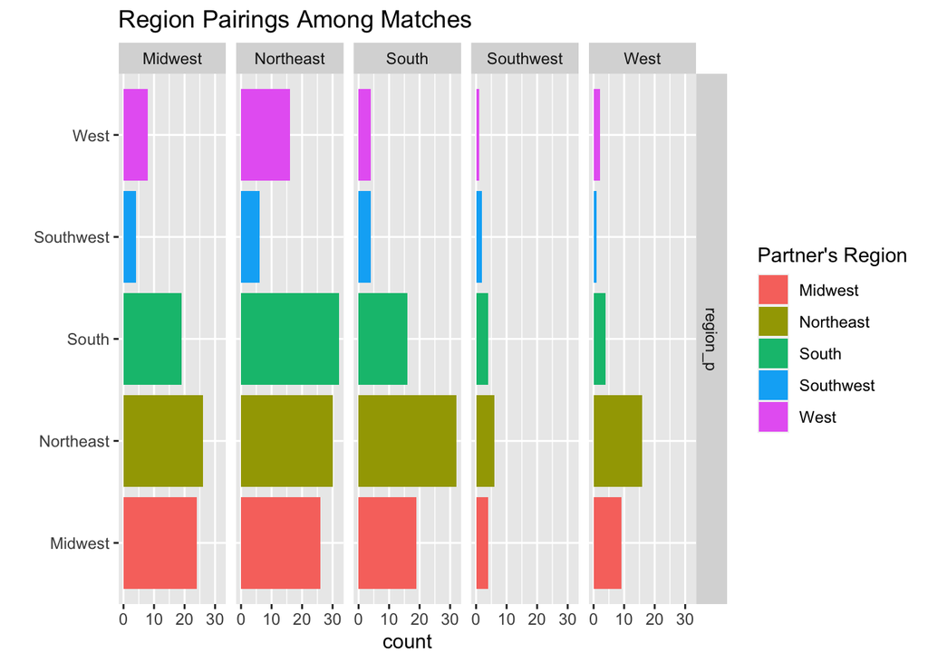

```r
df9 <- matches[, c("region", "region_p")]
df9 <- df9[!(df9$region=="" | df9$region_p==""| is.na(df9$region) | is.na(df9$region_p)), ]
ggplot(melt(df9, id.var = "region"), aes(x=value, fill=value)) + geom_bar() + facet_grid (variable ~ region) + xlab("") + coord_flip() + scale_fill_discrete("Partner's Region") + ggtitle("Region Pairings Among Matches")
```